# **Business Metrics Analysis**

**Research objective:** analyse the results of the marketing campaign for the Procrastinate Pro+ app and find out why it is making losses

**Data:**

- visits: `visits_info_short.csv`;
- orders: `orders_info_short.csv`;
- cost: `costs_info_short.csv`.

**Course of research**:

1. Obtaining general information about the data
2. Data preprocessing
   - column headers
   - data types
   - data gaps
   - duplicates
3. Functions for calculating and analysing LTV, ROI, retention, and conversion
   - `get_profiles()`
   - `get_retention()`
   - `get_conversion()`
   - `get_ltv()`
   - `filter_data()`
   - `plot_retention()`
   - `plot_converion()`
   - `plot_ltv_roi()`
4. Data analysis
   - users profiles
   - countries
   - devices
   - marketing channels
5. Marketing
   - total amount spent on marketing
   - distribution of expenditures by advertising sources
   - visualisation of expenditure trends over time
   - customer acquisition cost
6. Return on investment
   - LTV & ROI plots
   - user converions and its dynamics
   - user retention and its dynamcis
   - ROI by device
   - ROI by country
   - ROI by advertasing channel
   - user conversion by channel
   - user retention by channel
7. Overall conclusion

## Obtaining general information about the data

```python
import pandas as pd
import numpy as np
from datetime import datetime, timedelta
from matplotlib import pyplot as plt
```

```python
visits, orders, costs = (
    pd.read_csv('visits_info_short.csv'),
    pd.read_csv('orders_info_short.csv'),
    pd.read_csv('costs_info_short.csv')
)
```

```python
visits.head(5)
```

|  | User Id | Region | Device | Channel | Session Start | Session End |
| --- | --- | --- | --- | --- | --- | --- |
| 0 | 981449118918 | United States | iPhone | organic | 2019-05-01 02:36:01 | 2019-05-01 02:45:01 |
| 1 | 278965908054 | United States | iPhone | organic | 2019-05-01 04:46:31 | 2019-05-01 04:47:35 |
| 2 | 590706206550 | United States | Mac | organic | 2019-05-01 14:09:25 | 2019-05-01 15:32:08 |
| 3 | 326433527971 | United States | Android | TipTop | 2019-05-01 00:29:59 | 2019-05-01 00:54:25 |
| 4 | 349773784594 | United States | Mac | organic | 2019-05-01 03:33:35 | 2019-05-01 03:57:40 |

```python
orders.head(5)
```

|  | User Id | Event Dt | Revenue |
| --- | --- | --- | --- |
| 0 | 188246423999 | 2019-05-01 23:09:52 | 4.99 |
| 1 | 174361394180 | 2019-05-01 12:24:04 | 4.99 |
| 2 | 529610067795 | 2019-05-01 11:34:04 | 4.99 |
| 3 | 319939546352 | 2019-05-01 15:34:40 | 4.99 |
| 4 | 366000285810 | 2019-05-01 13:59:51 | 4.99 |

```python
costs.head(5)
```

|  | dt | Channel | costs |
| --- | --- | --- | --- |
| 0 | 2019-05-01 | FaceBoom | 113.3 |
| 1 | 2019-05-02 | FaceBoom | 78.1 |
| 2 | 2019-05-03 | FaceBoom | 85.8 |
| 3 | 2019-05-04 | FaceBoom | 136.4 |
| 4 | 2019-05-05 | FaceBoom | 122.1 |

## Data preprocessing

### column headers

In each of the dataframes, let's standardize the column headers.

```python
visits = visits.rename(columns={
    'User Id': 'user_id',
    'Region': 'region',
    'Device': 'device',
    'Channel': 'channel',
    'Session Start': 'session_start',
    'Session End': 'session_end'
})

visits.head(5)
```

|  | user_id | region | device | channel | session_start | session_end |
| --- | --- | --- | --- | --- | --- | --- |
| 0 | 981449118918 | United States | iPhone | organic | 2019-05-01 02:36:01 | 2019-05-01 02:45:01 |
| 1 | 278965908054 | United States | iPhone | organic | 2019-05-01 04:46:31 | 2019-05-01 04:47:35 |
| 2 | 590706206550 | United States | Mac | organic | 2019-05-01 14:09:25 | 2019-05-01 15:32:08 |
| 3 | 326433527971 | United States | Android | TipTop | 2019-05-01 00:29:59 | 2019-05-01 00:54:25 |
| 4 | 349773784594 | United States | Mac | organic | 2019-05-01 03:33:35 | 2019-05-01 03:57:40 |

```python
orders = orders.rename(columns={
    'User Id': 'user_id',
    'Event Dt': 'event_dt',
    'Revenue': 'revenue'
})

orders.head(5)
```

|  | user_id | event_dt | revenue |
| --- | --- | --- | --- |
| 0 | 188246423999 | 2019-05-01 23:09:52 | 4.99 |
| 1 | 174361394180 | 2019-05-01 12:24:04 | 4.99 |
| 2 | 529610067795 | 2019-05-01 11:34:04 | 4.99 |
| 3 | 319939546352 | 2019-05-01 15:34:40 | 4.99 |
| 4 | 366000285810 | 2019-05-01 13:59:51 | 4.99 |

```python
costs = costs.rename(columns={
    'Channel': 'channel'
})

costs.head(5)
```

|  | dt | channel | costs |
| --- | --- | --- | --- |
| 0 | 2019-05-01 | FaceBoom | 113.3 |
| 1 | 2019-05-02 | FaceBoom | 78.1 |
| 2 | 2019-05-03 | FaceBoom | 85.8 |
| 3 | 2019-05-04 | FaceBoom | 136.4 |
| 4 | 2019-05-05 | FaceBoom | 122.1 |

### Data types

```python
visits.info()
```

```
<class 'pandas.core.frame.DataFrame'>
RangeIndex: 309901 entries, 0 to 309900
Data columns (total 6 columns):
 #   Column         Non-Null Count   Dtype
---  ------         --------------   -----
 0   user_id        309901 non-null  int64
 1   region         309901 non-null  object
 2   device         309901 non-null  object
 3   channel        309901 non-null  object
 4   session_start  309901 non-null  object
 5   session_end    309901 non-null  object
dtypes: int64(1), object(5)
memory usage: 14.2+ MB
```

```python
orders.info()
```

```
<class 'pandas.core.frame.DataFrame'>
RangeIndex: 40212 entries, 0 to 40211
Data columns (total 3 columns):
 #   Column    Non-Null Count  Dtype
---  ------    --------------  -----
 0   user_id   40212 non-null  int64
 1   event_dt  40212 non-null  object
 2   revenue   40212 non-null  float64
dtypes: float64(1), int64(1), object(1)
memory usage: 942.6+ KB
```

```python
costs.info()
```

```
<class 'pandas.core.frame.DataFrame'>
RangeIndex: 1800 entries, 0 to 1799
Data columns (total 3 columns):
 #   Column   Non-Null Count  Dtype
---  ------   --------------  -----
 0   dt       1800 non-null   object
 1   channel  1800 non-null   object
 2   costs    1800 non-null   float64
dtypes: float64(1), object(2)
memory usage: 42.3+ KB
```

Let's transform the data type in columns with time to the `datetime` format.

```python
visits['session_start'] = pd.to_datetime(visits['session_start'])
visits['session_end'] = pd.to_datetime(visits['session_end'])
orders['event_dt'] = pd.to_datetime(orders['event_dt'])
costs['dt'] = pd.to_datetime(costs['dt']).dt.date
```

### Data gaps

There are no data gaps in datasets.

### Duplicates

#### Full duplicates

```python
visits.duplicated().sum()
```

```
0
```

```python
orders.duplicated().sum()
```

```
0
```

```python
costs.duplicated().sum()
```

```
0
```

There are no full duplicates in the datasets.

#### Fuzzy duplicates

##### dataset `visits`

Let's check whether the columns `region`, `device`, and `channel` contain partial duplicates. We will use the `unique` method.

```python
visits['region'].unique()
```

```
array(['United States', 'UK', 'France', 'Germany'], dtype=object)
```

```python
visits['device'].unique()
```

```
array(['iPhone', 'Mac', 'Android', 'PC'], dtype=object)
```

```python
visits['channel'].unique()
```

```
array(['organic', 'TipTop', 'RocketSuperAds', 'YRabbit', 'FaceBoom',
       'MediaTornado', 'AdNonSense', 'LeapBob', 'WahooNetBanner',
       'OppleCreativeMedia', 'lambdaMediaAds'], dtype=object)
```

There are no partial duplicates in the `visits` dataset.

##### dataset `orders`

There are no columns in this dataset that could have implicit duplicates.

```python
orders.head(5)
```

|  | user_id | event_dt | revenue |
| --- | --- | --- | --- |
| 0 | 188246423999 | 2019-05-01 23:09:52 | 4.99 |
| 1 | 174361394180 | 2019-05-01 12:24:04 | 4.99 |
| 2 | 529610067795 | 2019-05-01 11:34:04 | 4.99 |
| 3 | 319939546352 | 2019-05-01 15:34:40 | 4.99 |
| 4 | 366000285810 | 2019-05-01 13:59:51 | 4.99 |

##### dataset `costs`

We will check the `channel` column for the presence of implicit duplicates.

```python
costs['channel'].unique()
```

```
array(['FaceBoom', 'MediaTornado', 'RocketSuperAds', 'TipTop', 'YRabbit',
       'AdNonSense', 'LeapBob', 'OppleCreativeMedia', 'WahooNetBanner',
       'lambdaMediaAds'], dtype=object)
```

there are no partial duplicates.

## Functions for calculating and analyzing LTV, ROI, retention, and conversion

Let's create functions for calculating and analyzing LTV, ROI, retention, and conversion.

These are functions for calculating metrics:

- `get_profiles()` — for creating user profiles,
- `get_retention()` — for calculating retention rate,
- `get_conversion()` — for calculating conversion rate,
- `get_ltv()` — for calculating customer lifetime value (LTV).

Functions for plots:

- `filter_data()` — for smoothing data,
- `plot_retention()` — for plotting retention rate,
- `plot_conversion()` — for plotting conversion rate,
- `plot_ltv_roi` — for visualizing customer lifetime value (LTV) and return on investment (ROI).

### `get_profiles()`

```python
def get_profiles(sessions, orders, ad_costs):

    profiles = (
        sessions.sort_values(by=['user_id', 'session_start'])
        .groupby('user_id')
        .agg(
            {
                'session_start': 'first',
                'channel': 'first',
                'device': 'first',
                'region': 'first',
            }
        )
        .rename(columns={'session_start': 'first_ts'})
        .reset_index()
    )

    profiles['dt'] = profiles['first_ts'].dt.date
    profiles['month'] = profiles['first_ts'].astype('datetime64[M]')

    profiles['payer'] = profiles['user_id'].isin(orders['user_id'].unique())

    new_users = (
        profiles.groupby(['dt', 'channel'])
        .agg({'user_id': 'nunique'})
        .rename(columns={'user_id': 'unique_users'})
        .reset_index()
    )

    ad_costs = ad_costs.merge(new_users, on=['dt', 'channel'], how='left')

    ad_costs['acquisition_cost'] = ad_costs['costs'] / ad_costs['unique_users']

    profiles = profiles.merge(
        ad_costs[['dt', 'channel', 'acquisition_cost']],
        on=['dt', 'channel'],
        how='left',
    )

    profiles['acquisition_cost'] = profiles['acquisition_cost'].fillna(0)

    return profiles
```

```python
#let's check whether the function works

profiles = get_profiles(visits, orders, costs)
profiles.head(10)
```

|  | user_id | first_ts | channel | device | region | dt | month | payer | acquisition_cost |
| --- | --- | --- | --- | --- | --- | --- | --- | --- | --- |
| 0 | 599326 | 2019-05-07 20:58:57 | FaceBoom | Mac | United States | 2019-05-07 | 2019-05-07 20:58:57 | True | 1.088172 |
| 1 | 4919697 | 2019-07-09 12:46:07 | FaceBoom | iPhone | United States | 2019-07-09 | 2019-07-09 12:46:07 | False | 1.107237 |
| 2 | 6085896 | 2019-10-01 09:58:33 | organic | iPhone | France | 2019-10-01 | 2019-10-01 09:58:33 | False | 0.000000 |
| 3 | 22593348 | 2019-08-22 21:35:48 | AdNonSense | PC | Germany | 2019-08-22 | 2019-08-22 21:35:48 | False | 0.988235 |
| 4 | 31989216 | 2019-10-02 00:07:44 | YRabbit | iPhone | United States | 2019-10-02 | 2019-10-02 00:07:44 | False | 0.230769 |
| 5 | 34186288 | 2019-05-09 17:29:23 | organic | Android | United States | 2019-05-09 | 2019-05-09 17:29:23 | False | 0.000000 |
| 6 | 38448301 | 2019-08-16 11:56:00 | organic | Android | United States | 2019-08-16 | 2019-08-16 11:56:00 | False | 0.000000 |
| 7 | 46006712 | 2019-06-30 03:46:29 | AdNonSense | Android | France | 2019-06-30 | 2019-06-30 03:46:29 | True | 1.008000 |
| 8 | 58263264 | 2019-05-11 19:18:43 | FaceBoom | iPhone | United States | 2019-05-11 | 2019-05-11 19:18:43 | False | 1.128205 |
| 9 | 59835779 | 2019-05-11 21:13:47 | MediaTornado | iPhone | United States | 2019-05-11 | 2019-05-11 21:13:47 | False | 0.250435 |

### `get_retention()`

```python
def get_retention(
    profiles,
    sessions,
    observation_date,
    horizon_days,
    dimensions=[],
    ignore_horizon=False,
):

    dimensions = ['payer'] + dimensions

    last_suitable_acquisition_date = observation_date
    if not ignore_horizon:
        last_suitable_acquisition_date = observation_date - timedelta(
            days=horizon_days - 1
        )
    result_raw = profiles.query('dt <= @last_suitable_acquisition_date')

    result_raw = result_raw.merge(
        sessions[['user_id', 'session_start']], on='user_id', how='left'
    )
    result_raw['lifetime'] = (
        result_raw['session_start'] - result_raw['first_ts']
    ).dt.days

    def group_by_dimensions(df, dims, horizon_days):
        result = df.pivot_table(
            index=dims, columns='lifetime', values='user_id', aggfunc='nunique'
        )
        cohort_sizes = (
            df.groupby(dims)
            .agg({'user_id': 'nunique'})
            .rename(columns={'user_id': 'cohort_size'})
        )
        result = cohort_sizes.merge(result, on=dims, how='left').fillna(0)
        result = result.div(result['cohort_size'], axis=0)
        result = result[['cohort_size'] + list(range(horizon_days))]
        result['cohort_size'] = cohort_sizes
        return result

    result_grouped = group_by_dimensions(result_raw, dimensions, horizon_days)

    result_in_time = group_by_dimensions(
        result_raw, dimensions + ['dt'], horizon_days
    )

    return result_raw, result_grouped, result_in_time
```

```python
retention_raw, retention, retention_history = get_retention(
    profiles, visits, datetime(2019, 11, 1).date(), 14)
retention
```

| payer | cohort_size | 0 | 1 | 2 | 3 | 4 | 5 | 6 | 7 | 8 | 9 | 10 | 11 | 12 | 13 |
| --- | --- | --- | --- | --- | --- | --- | --- | --- | --- | --- | --- | --- | --- | --- | --- |
| False | 134200 | 1.0 | 0.176811 | 0.086356 | 0.051468 | 0.034493 | 0.024516 | 0.018443 | 0.013994 | 0.011818 | 0.009478 | 0.007750 | 0.006610 | 0.005872 | 0.004575 |
| True | 8420 | 1.0 | 0.404751 | 0.316746 | 0.259739 | 0.226841 | 0.209264 | 0.187767 | 0.173634 | 0.162589 | 0.150950 | 0.149406 | 0.137173 | 0.133373 | 0.121496 |

### `get_conversion()`

```python
def get_conversion(
    profiles,
    purchases,
    observation_date,
    horizon_days,
    dimensions=[],
    ignore_horizon=False,
):

    last_suitable_acquisition_date = observation_date
    if not ignore_horizon:
        last_suitable_acquisition_date = observation_date - timedelta(
            days=horizon_days - 1
        )
    result_raw = profiles.query('dt <= @last_suitable_acquisition_date')

    first_purchases = (
        purchases.sort_values(by=['user_id', 'event_dt'])
        .groupby('user_id')
        .agg({'event_dt': 'first'})
        .reset_index()
    )

    result_raw = result_raw.merge(
        first_purchases[['user_id', 'event_dt']], on='user_id', how='left'
    )

    result_raw['lifetime'] = (
        result_raw['event_dt'] - result_raw['first_ts']
    ).dt.days

    if len(dimensions) == 0:
        result_raw['cohort'] = 'All users'
        dimensions = dimensions + ['cohort']

    def group_by_dimensions(df, dims, horizon_days):
        result = df.pivot_table(
            index=dims, columns='lifetime', values='user_id', aggfunc='nunique'
        )
        result = result.fillna(0).cumsum(axis = 1)
        cohort_sizes = (
            df.groupby(dims)
            .agg({'user_id': 'nunique'})
            .rename(columns={'user_id': 'cohort_size'})
        )
        result = cohort_sizes.merge(result, on=dims, how='left').fillna(0)

        result = result.div(result['cohort_size'], axis=0)
        result = result[['cohort_size'] + list(range(horizon_days))]
        result['cohort_size'] = cohort_sizes
        return result

    result_grouped = group_by_dimensions(result_raw, dimensions, horizon_days)

    if 'cohort' in dimensions:
        dimensions = []

    result_in_time = group_by_dimensions(
        result_raw, dimensions + ['dt'], horizon_days
    )

    return result_raw, result_grouped, result_in_time
```

```python
conversion_raw, conversion, conversion_history = get_conversion(
    profiles, orders, datetime(2019, 11, 1).date(), 14
)

conversion
```

| cohort | cohort_size | 0.0 | 1.0 | 2.0 | 3.0 | 4.0 | 5.0 | 6.0 | 7.0 | 8.0 | 9.0 | 10.0 | 11.0 | 12.0 | 13.0 |
| --- | --- | --- | --- | --- | --- | --- | --- | --- | --- | --- | --- | --- | --- | --- | --- |
| All users | 142620 | 0.04092 | 0.046705 | 0.049516 | 0.051522 | 0.052973 | 0.053898 | 0.054677 | 0.055392 | 0.055946 | 0.056458 | 0.056738 | 0.056977 | 0.057145 | 0.057369 |

### `get_ltv()`

```python
def get_ltv(
    profiles,
    purchases,
    observation_date,
    horizon_days,
    dimensions=[],
    ignore_horizon=False,
):

    last_suitable_acquisition_date = observation_date
    if not ignore_horizon:
        last_suitable_acquisition_date = observation_date - timedelta(
            days=horizon_days - 1
        )
    result_raw = profiles.query('dt <= @last_suitable_acquisition_date')
    result_raw = result_raw.merge(
        purchases[['user_id', 'event_dt', 'revenue']], on='user_id', how='left'
    )

    result_raw['lifetime'] = (
        result_raw['event_dt'] - result_raw['first_ts']
    ).dt.days

    if len(dimensions) == 0:
        result_raw['cohort'] = 'All users'
        dimensions = dimensions + ['cohort']

    def group_by_dimensions(df, dims, horizon_days):
        result = df.pivot_table(
            index=dims, columns='lifetime', values='revenue', aggfunc='sum'
        )
        result = result.fillna(0).cumsum(axis=1)
        cohort_sizes = (
            df.groupby(dims)
            .agg({'user_id': 'nunique'})
            .rename(columns={'user_id': 'cohort_size'})
        )
        result = cohort_sizes.merge(result, on=dims, how='left').fillna(0)
        result = result.div(result['cohort_size'], axis=0)
        result = result[['cohort_size'] + list(range(horizon_days))]
        result['cohort_size'] = cohort_sizes

        cac = df[['user_id', 'acquisition_cost'] + dims].drop_duplicates()

        cac = (
            cac.groupby(dims)
            .agg({'acquisition_cost': 'mean'})
            .rename(columns={'acquisition_cost': 'cac'})
        )

        roi = result.div(cac['cac'], axis=0)

        roi = roi[~roi['cohort_size'].isin([np.inf])]

        roi['cohort_size'] = cohort_sizes

        roi['cac'] = cac['cac']

        roi = roi[['cohort_size', 'cac'] + list(range(horizon_days))]

        return result, roi

    result_grouped, roi_grouped = group_by_dimensions(
        result_raw, dimensions, horizon_days
    )

    if 'cohort' in dimensions:
        dimensions = []

    result_in_time, roi_in_time = group_by_dimensions(
        result_raw, dimensions + ['dt'], horizon_days
    )

    return (
        result_raw,
        result_grouped,
        result_in_time,
        roi_grouped,
        roi_in_time
    )
```

```python
ltv_raw, ltv_grouped, ltv_history, roi_grouped, roi_history = get_ltv(
    profiles, orders, datetime(2019, 11, 1).date(), 14)


ltv_grouped
```

| cohort | cohort_size | 0.0 | 1.0 | 2.0 | 3.0 | 4.0 | 5.0 | 6.0 | 7.0 | 8.0 | 9.0 | 10.0 | 11.0 | 12.0 | 13.0 |
| --- | --- | --- | --- | --- | --- | --- | --- | --- | --- | --- | --- | --- | --- | --- | --- |
| All users | 142620 | 0.241267 | 0.310905 | 0.364073 | 0.408661 | 0.447512 | 0.481909 | 0.513263 | 0.541481 | 0.569211 | 0.594565 | 0.617813 | 0.639767 | 0.661289 | 0.680757 |

### `filter_data()`

```python
def filter_data(df, window):
    for column in df.columns.values:
        df[column] = df[column].rolling(window).mean()
    return df
```

### `plot_retention()`

```python
def plot_retention(retention, retention_history, horizon, window=7):

    plt.figure(figsize=(15, 10))

    retention = retention.drop(columns=['cohort_size', 0])
    retention_history = retention_history.drop(columns=['cohort_size'])[
        [horizon - 1]
    ]

    if retention.index.nlevels == 1:
        retention['cohort'] = 'All users'
        retention = retention.reset_index().set_index(['cohort', 'payer'])

    ax1 = plt.subplot(2, 2, 1)
    retention.query('payer == True').droplevel('payer').T.plot(
        grid=True, ax=ax1
    )
    plt.legend()
    plt.xlabel('Lifetime')
    plt.title('Retention of paying users')

    ax2 = plt.subplot(2, 2, 2, sharey=ax1)
    retention.query('payer == False').droplevel('payer').T.plot(
        grid=True, ax=ax2
    )
    plt.legend()
    plt.xlabel('Lifetime')
    plt.title('Retention of non-paying users')

    ax3 = plt.subplot(2, 2, 3)
    columns = [
        name
        for name in retention_history.index.names
        if name not in ['dt', 'payer']
    ]

    filtered_data = retention_history.query('payer == True').pivot_table(
        index='dt', columns=columns, values=horizon - 1, aggfunc='mean'
    )
    filter_data(filtered_data, window).plot(grid=True, ax=ax3)
    plt.xlabel('Acquisition date')
    plt.title(
        'The dynamics of retaining paying users on the {} day'.format(
            horizon
        )
    )

    ax4 = plt.subplot(2, 2, 4, sharey=ax3)
    filtered_data = retention_history.query('payer == False').pivot_table(
        index='dt', columns=columns, values=horizon - 1, aggfunc='mean'
    )
    filter_data(filtered_data, window).plot(grid=True, ax=ax4)
    plt.xlabel('Acquisition date')
    plt.title(
        'The dynamics of retaining non-paying users on the {} day'.format(
            horizon
        )
    )

    plt.tight_layout()
    plt.show()
```

### `plot_conversion()`

```python
def plot_conversion(conversion, conversion_history, horizon, window=7):

    plt.figure(figsize=(15, 5))

    conversion = conversion.drop(columns=['cohort_size'])
    conversion_history = conversion_history.drop(columns=['cohort_size'])[
        [horizon - 1]
    ]

    ax1 = plt.subplot(1, 2, 1)
    conversion.T.plot(grid=True, ax=ax1)
    plt.legend()
    plt.xlabel('Lifetime')
    plt.title('Conversion')

    ax2 = plt.subplot(1, 2, 2, sharey=ax1)
    columns = [
        name for name in conversion_history.index.names if name not in ['dt']
    ]
    filtered_data = conversion_history.pivot_table(
        index='dt', columns=columns, values=horizon - 1, aggfunc='mean'
    )
    filter_data(filtered_data, window).plot(grid=True, ax=ax2)
    plt.xlabel('Acquisition date')
    plt.title('The conversion rate dynamics on the {} day.'.format(horizon))

    plt.tight_layout()
    plt.show()
```

### `plot_ltv_roi`

```python
def plot_ltv_roi(ltv, ltv_history, roi, roi_history, horizon, window=7):

    plt.figure(figsize=(20, 10))

    ltv = ltv.drop(columns=['cohort_size'])
    ltv_history = ltv_history.drop(columns=['cohort_size'])[[horizon - 1]]

    cac_history = roi_history[['cac']]

    roi = roi.drop(columns=['cohort_size', 'cac'])
    roi_history = roi_history.drop(columns=['cohort_size', 'cac'])[
        [horizon - 1]
    ]

    ax1 = plt.subplot(2, 3, 1)
    ltv.T.plot(grid=True, ax=ax1)
    plt.legend()
    plt.xlabel('Lifetime')
    plt.title('LTV')

    ax2 = plt.subplot(2, 3, 2, sharey=ax1)
    columns = [name for name in ltv_history.index.names if name not in ['dt']]
    filtered_data = ltv_history.pivot_table(
        index='dt', columns=columns, values=horizon - 1, aggfunc='mean'
    )
    filter_data(filtered_data, window).plot(grid=True, ax=ax2)
    plt.xlabel('Acquisition date')
    plt.title('LTV dynamics on the {} day'.format(horizon))

    ax3 = plt.subplot(2, 3, 3, sharey=ax1)
    columns = [name for name in cac_history.index.names if name not in ['dt']]
    filtered_data = cac_history.pivot_table(
        index='dt', columns=columns, values='cac', aggfunc='mean'
    )
    filter_data(filtered_data, window).plot(grid=True, ax=ax3)
    plt.xlabel('Acquisition date')
    plt.title('Users acquisition cost dynamics')

    ax4 = plt.subplot(2, 3, 4)
    roi.T.plot(grid=True, ax=ax4)
    plt.axhline(y=1, color='red', linestyle='--', label='Retunr on investment')
    plt.legend()
    plt.xlabel('Lifetime')
    plt.title('ROI')

    ax5 = plt.subplot(2, 3, 5, sharey=ax4)
    columns = [name for name in roi_history.index.names if name not in ['dt']]
    filtered_data = roi_history.pivot_table(
        index='dt', columns=columns, values=horizon - 1, aggfunc='mean'
    )
    filter_data(filtered_data, window).plot(grid=True, ax=ax5)
    plt.axhline(y=1, color='red', linestyle='--', label='Retunr on investment')
    plt.xlabel('Acquisition date')
    plt.title('ROI dynamics on {} day'.format(horizon))

    plt.tight_layout()
    plt.show()
```

## Data analysis

### Users profiles

Let's get users profiles and define min and max acquisition dates.

```python
profiles = get_profiles(visits, orders, costs)
profiles.head(10)
```

|  | user_id | first_ts | channel | device | region | dt | month | payer | acquisition_cost |
| --- | --- | --- | --- | --- | --- | --- | --- | --- | --- |
| 0 | 599326 | 2019-05-07 20:58:57 | FaceBoom | Mac | United States | 2019-05-07 | 2019-05-07 20:58:57 | True | 1.088172 |
| 1 | 4919697 | 2019-07-09 12:46:07 | FaceBoom | iPhone | United States | 2019-07-09 | 2019-07-09 12:46:07 | False | 1.107237 |
| 2 | 6085896 | 2019-10-01 09:58:33 | organic | iPhone | France | 2019-10-01 | 2019-10-01 09:58:33 | False | 0.000000 |
| 3 | 22593348 | 2019-08-22 21:35:48 | AdNonSense | PC | Germany | 2019-08-22 | 2019-08-22 21:35:48 | False | 0.988235 |
| 4 | 31989216 | 2019-10-02 00:07:44 | YRabbit | iPhone | United States | 2019-10-02 | 2019-10-02 00:07:44 | False | 0.230769 |
| 5 | 34186288 | 2019-05-09 17:29:23 | organic | Android | United States | 2019-05-09 | 2019-05-09 17:29:23 | False | 0.000000 |
| 6 | 38448301 | 2019-08-16 11:56:00 | organic | Android | United States | 2019-08-16 | 2019-08-16 11:56:00 | False | 0.000000 |
| 7 | 46006712 | 2019-06-30 03:46:29 | AdNonSense | Android | France | 2019-06-30 | 2019-06-30 03:46:29 | True | 1.008000 |
| 8 | 58263264 | 2019-05-11 19:18:43 | FaceBoom | iPhone | United States | 2019-05-11 | 2019-05-11 19:18:43 | False | 1.128205 |
| 9 | 59835779 | 2019-05-11 21:13:47 | MediaTornado | iPhone | United States | 2019-05-11 | 2019-05-11 21:13:47 | False | 0.250435 |

```python
min_analysis_date = profiles['first_ts'].min()
max_analysis_date = profiles['first_ts'].max()

print(f'Min acquisition date: {min_analysis_date}')
print(f'Max acquisition date: {max_analysis_date}')
```

```
Min acquisition date: 2019-05-01 00:00:41
Max acquisition date: 2019-10-27 23:59:04
```

In our dataset, the data is provided from May 1st to October 27th, 2019 - a span of 6 months. This corresponds to the dates specified in the task description

### Countries

Find out from which countries users come to the app and which country has the most paying users. Build a table showing the number of users and the proportion of paying users from each country.

```python
countries = profiles.pivot_table(
    index='region', columns='payer', values='user_id', aggfunc='nunique').\
    rename(columns={True: 'paying', False: 'not_paying'})
countries['all_users'] = profiles.groupby('region').agg({'user_id': 'nunique'})
countries['paying %'] = profiles.groupby('region').agg({'payer': 'mean'})
countries['paying %'] = round(countries['paying %'] * 100, 2)
countries.sort_values(by='paying %', ascending=False)
```

| payer region | not_paying | paying | all_users | paying % |
| --- | --- | --- | --- | --- |
| United States | 93100 | 6902 | 100002 | 6.90 |
| Germany | 14365 | 616 | 14981 | 4.11 |
| UK | 16875 | 700 | 17575 | 3.98 |
| France | 16787 | 663 | 17450 | 3.80 |

The application is used in four countries: USA, Germany, UK, France.

The percentage of paying users is highest in the USA - 6.9%. This is 2.8% more than in Germany, which follows the US. The last place is occupied by France, where the percentage of paying users is almost twice as low as in the USA.

### Devices

Let's take a look at what devices customers are using and what devices are preferred by paying users.

```python
devices = profiles.pivot_table(
    index='device', columns='payer', values='user_id', aggfunc='nunique').\
    rename(columns={True:'paying', False:'not_paying'})
devices['all_users'] = profiles.groupby('device').agg({'user_id': 'nunique'})
devices['paying %'] = profiles.groupby('device').agg({'payer': 'mean'})
devices['paying %'] = round(devices['paying %'] * 100, 2)
devices.sort_values(by='paying %', ascending=False)
```

| payer device | not_paying | paying | all_users | paying % |
| --- | --- | --- | --- | --- |
| Mac | 28130 | 1912 | 30042 | 6.36 |
| iPhone | 51097 | 3382 | 54479 | 6.21 |
| Android | 32982 | 2050 | 35032 | 5.85 |
| PC | 28918 | 1537 | 30455 | 5.05 |

The maximum percentage of paying users here is close to the country statistics, but the difference between the maximum and minimum values is not so big.

Those who use Apple devices have the most paying users.

- Mac - 6.36%
- iPhone - 6.21%

For the rest of the devices, the percentage of paying users falls below 6%

- Andriod - 5.85%
- PC - 5.05%

The most promising device is the iPhone: the Procrastinate Pro app is most used from this device (almost twice as many users as on MAC), and the percentage of paying users is almost as high as on MAC.

### Marketing channels

Let's see what advertising channels were used and which ones attracted the most users.

```python
ad_channels = profiles.pivot_table(
    index='channel', columns='payer', values='user_id', aggfunc='nunique').\
    rename(columns={True: 'paying', False: 'not_paying'})
ad_channels['all_users'] = profiles.groupby('channel').agg({'user_id': 'nunique'})
ad_channels['paying %'] = round(((profiles.groupby('channel').agg({'payer': 'mean'})) * 100), 2)
ad_channels.sort_values(by='paying %', ascending=False)
```

| payer channel | not_paying | paying | all_users | paying % |
| --- | --- | --- | --- | --- |
| FaceBoom | 25587 | 3557 | 29144 | 12.20 |
| AdNonSense | 3440 | 440 | 3880 | 11.34 |
| lambdaMediaAds | 1924 | 225 | 2149 | 10.47 |
| TipTop | 17683 | 1878 | 19561 | 9.60 |
| RocketSuperAds | 4096 | 352 | 4448 | 7.91 |
| WahooNetBanner | 8100 | 453 | 8553 | 5.30 |
| YRabbit | 4147 | 165 | 4312 | 3.83 |
| MediaTornado | 4208 | 156 | 4364 | 3.57 |
| LeapBob | 8291 | 262 | 8553 | 3.06 |
| OppleCreativeMedia | 8372 | 233 | 8605 | 2.71 |
| organic | 55279 | 1160 | 56439 | 2.06 |

Procraqstinate Pro app used 10 different marketing channels. A big difference in the percentage of paying users is noticeable.

Interestingly, the app has the most organic users with 56'439, but among them the lowest percentage of paying users with only 2.06%, the very last place.

TipTop channel is in the second place by the total number of attracted users (19561), and the percentage of paying users is not so different from the leaders - 9.6%.

- YRabbit
- MediaTornado
- LeapBob
- OppleCreativeMedia

## Marketing

- Calculate the total amount spent on marketing.
- Find out how spending is distributed by advertising sources, i.e. how much money was spent on each source.
- Build a visualisation of the dynamics of spending over time (by week and month) for each source. Try to reflect this on one graph.
- Find out how much it cost on average to attract one user (CAC) from each source. Use user profiles.

### Total amount spent on marketing

```python
round(sum(profiles['acquisition_cost']))
```

```
105497
```

A total of $105'497 was spent on advertising campaigns.

### Distribution of expenditures by advertising sources

```python
channel_cost = profiles.query('channel != "organic"')\
    .pivot_table(
    index='channel', values='acquisition_cost', aggfunc='sum')\
    .sort_values(by='acquisition_cost', ascending=False)

channel_cost['% invested'] = round((channel_cost['acquisition_cost'] / sum(profiles['acquisition_cost']) * 100)\
                                   , 2)
channel_cost
```

| channel | acquisition_cost | % invested |
| --- | --- | --- |
| TipTop | 54751.30 | 51.90 |
| FaceBoom | 32445.60 | 30.75 |
| WahooNetBanner | 5151.00 | 4.88 |
| AdNonSense | 3911.25 | 3.71 |
| OppleCreativeMedia | 2151.25 | 2.04 |
| RocketSuperAds | 1833.00 | 1.74 |
| LeapBob | 1797.60 | 1.70 |
| lambdaMediaAds | 1557.60 | 1.48 |
| MediaTornado | 954.48 | 0.90 |
| YRabbit | 944.22 | 0.90 |

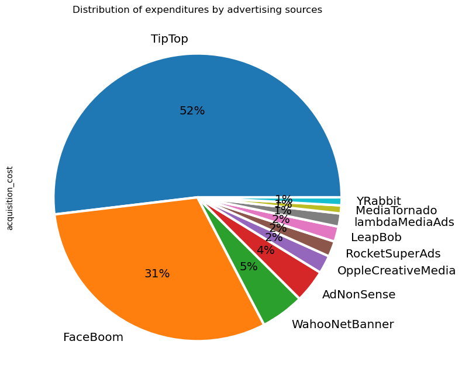

```python
channel_cost.plot(
    kind='pie',
    y='acquisition_cost',
    autopct='%1.0f%%',
    wedgeprops={'linewidth': 3.0, 'edgecolor': 'white'},
    textprops={'size': 'x-large'},
    legend=False,
    title='Distribution of expenditures by advertising sources',
    figsize=(8, 8)
);
```

83% of the total amount invested in advertising was spent on two channels: TipTop (52%, more than half of the total budget) and FaceBoom (31%).

As we remember from the previous table, FaceBoom attracts the most users: 22 thousand less was spent on advertising on this channel, but it attracted 10 thousand more users, of which 2.6% more moved to the category of paid users.

AdNonSense and lambdaMediaAds channels are more effective than TipTop.

It became clear why the other channels attracted so few users. The other 8 channels accounted for only 17% of the total amount spent on advertising.

### Visualisation of expenditure trends over time

Let's build a visualisation of the dynamics of expenditure change over time (by week and month) for each source.

Let's build separate graphs:

1. for the two leading platforms - TipTop and FaceBoom
2. for the other platforms

Advertising costs in these two groups differ by an order of magnitude. The graphs will be more illustrative if the platforms are divided into groups.

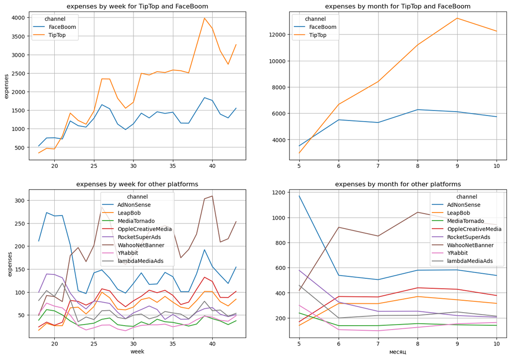

```python
# create a new dataframe and
# add columns with month and week
acq_cost_flow = profiles.query('channel != "organic"')

acq_cost_flow['month_number'] = acq_cost_flow['first_ts'].dt.month
acq_cost_flow['week'] = acq_cost_flow['first_ts'].dt.isocalendar().week

fig, axes = plt.subplots(2, 2, figsize=(16, 11))

# graphs for the two leading platforms by month
acq_cost_flow.query('channel == "TipTop" or channel == "FaceBoom"')\
.pivot_table(
    index='month_number', columns='channel', values='acquisition_cost', aggfunc='sum')\
    .plot(
    ax=axes[0, 1],
    grid=True,
    xlabel='',
    ylabel='',
    title='expenses by month for TipTop and FaceBoom'
)

# graphs for the rest of the platforms by month
acq_cost_flow.query('channel != "TipTop" and channel != "FaceBoom"')\
.pivot_table(
    index='month_number', columns='channel', values='acquisition_cost', aggfunc='sum')\
    .plot(
    ax=axes[1, 1],
    grid=True,
    xlabel='месяц',
    ylabel='',
    title='expenses by month for other platforms'
);

# graphs for the two leading platforms by week
acq_cost_flow.query('channel == "TipTop" or channel == "FaceBoom"')\
.pivot_table(
    index='week', columns='channel', values='acquisition_cost', aggfunc='sum')\
    .plot(
    ax=axes[0, 0],
    grid=True,
    xlabel='',
    ylabel='expenses',
    title='expenses by week for TipTop and FaceBoom'
)

# graphs for the rest of the platforms by week
acq_cost_flow.query('channel != "TipTop" and channel != "FaceBoom"')\
.pivot_table(
    index='week', columns='channel', values='acquisition_cost', aggfunc='sum')\
    .plot(
    ax=axes[1, 0],
    grid=True,
    xlabel='week',
    ylabel='expenses',
    title='expenses by week for other platforms'
);
```

1. monthly expenses for TipTop and FaceBoom

The ad spend on these two channels goes up smoothly from month to month. The chart shows that the expenses on TipTop channel go up sharply - from 4,000 to 12,000, but we remember from the previous tables that this channel brings much less users than FaceBoom, and there is a lower percentage of users moving to the paid category. Whereas the FaceBoom channel spend rises smoothly from 4k to 6k and stays at that level, and the adverts continue to attract users and provide the highest percentage of paying users. Ads on the TipTop channel are twice as expensive and much less effective.

1. expenses by week for TipTop and FaceBoom

The graph of expenses distribution by weeks repeats the distribution of expenses by months: on FaceBoom channel the expenses rise during the first 4 weeks and fluctuate around 1000 - 1500 per week without any big jumps. There is a spike to 1800 in week 39.

Spending on the TipTop channel from week to week follows the pattern of spending on the FaceBoom channel, but at a more "expensive" level. Up until week 25, spending on the two channels is about the same. After week 25, spending on the TipTop channel continues to increase and peaks at 4,000 in week 39.

1. expenses by month for the rest of the channels

In this group, the most expensive channel is WahooNetBanner. Spending for the first month rises from 400 to 900, stays at this level with slight fluctuations and peaks at around 1000 in week 8.

The other two channels - OppleCreativeMedia and LeapBob - repeat this pattern at a cheaper level: spending goes up in the first month, stays at 350-400 for the next two months. They reach their peak in August. There are no big fluctuations here.

Expenses on the other channels fall during the 1st month and without big fluctuations stay at the achieved level.

1. expenditures by week for the rest of the channels

There is a lot of noise in this graph: expenses rise or fall from week to week.

### Customer Acquisition Cost

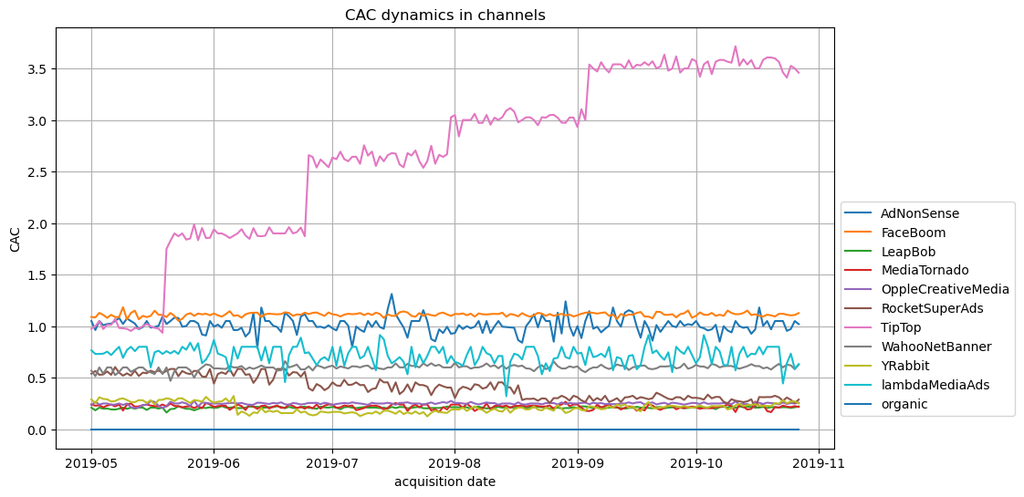

```python
profiles.pivot_table(
    index='dt', columns='channel', values='acquisition_cost', aggfunc='mean'
).plot(grid=True, figsize=(11, 6))
plt.ylabel('CAC')
plt.xlabel('acquisition date')
plt.title('CAC dynamics in channels')
plt.legend(bbox_to_anchor=(1, 0.6));
```

1. Something strange is happening with the **TipTop** channel: during the first month the cost of attraction increased by 1, and then continues to increase by about 0.5 every next month. At the same time, as we mentioned before, this channel is not the most effective in attracting new users.
2. In second place is the **FaceBoom** channel: the cost of attraction on this channel stably stays around 1.2. There are no strong fluctuations here.
3. AdNonSense channel - the cost of attraction fluctuates around 1, with some fluctuations.
4. lambdaMedaAds channel shows the biggest fluctuations, in the area from 0.5 to 0.8.

The RocketSuperAds channel is the only one where the cost of attraction started to fall at the end of June and by mid-August had dropped to 0.25.

## Return on investment

Using the LTV, ROI and CAC charts, analyse the return on advertising. Consider that the calendar is 1 November 2019, and the business plan stipulates that users should pay off no later than two weeks after engagement. Determine the need to include organic users in the analysis on your own.

- Analyse the return on advertising using LTV and ROI graphs, as well as graphs of LTV, CAC and ROI dynamics.
- Check user conversion and its dynamics. Do the same with user retention. Build and study conversion and retention graphs.
- Analyse ad ROI by device. Build LTV and ROI graphs, as well as graphs of LTV, CAC and ROI trends.
- Analyse ad ROI by country. Construct LTV and ROI graphs as well as LTV, CAC and ROI trend graphs.
- Analyse advertising ROI by advertising channel. Construct LTV and ROI graphs and graphs of LTV, CAC and ROI trends.
- Answer questions such as:
  - Does advertising aimed at attracting users in general pay off?
  - Which devices, countries and advertising channels can have a negative impact on ad ROI?
  - What might cause payback problems?

### LTV & ROI plots

Let's analyse the return on advertising using LTV and ROI graphs. To do this, let's call the functions `get_ltv` and `plot_ltv_roi`.

It is obvious that the problem is ineffective advertising on one of the channels, so let's exclude organic users from the analysis.

```python
observation_date = datetime(2019, 11, 1).date()
horizon_days = 14
```

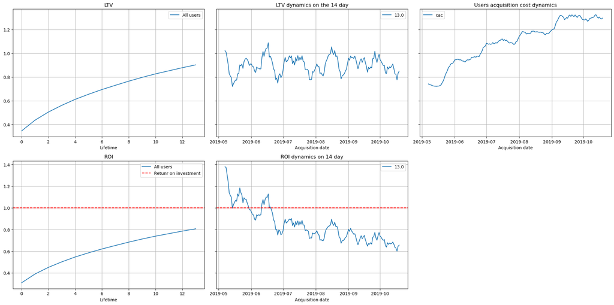

```python
profiles = profiles.query('channel != "organic"')

ltv_raw, ltv_grouped, ltv_history, roi_grouped, roi_history = get_ltv(
    profiles, orders, observation_date, horizon_days
)

plot_ltv_roi(ltv_grouped, ltv_history, roi_grouped, roi_history, horizon_days)
```

- the **LTV** curve is steadily rising and rises to 0.9 by the end of the review period
- **CAC** is not stable. The cost of attracting users starts to rise during the first month and jumps up sharply by the end of May. And continues to rise until the end of the observed period. This seems to be related to the increase in CAC on the TipTop channel that we saw in the past chart.
- Advertising does not pay off: the **ROI** curve reaches only 80% by the end of the period.

### User conversion and its dynamics

[figure not shown]

```python
conversion_raw, conversion_grouped, conversion_history = get_conversion(
    profiles, orders, observation_date, horizon_days
)

plot_conversion(conversion_grouped, conversion_history, horizon_days)
```

there are no abnormal thrends on conversion dynamcis

### User retention and its dynamics

[figure not shown]

```python
retention_raw, retention_grouped, retention_history = get_retention(
    profiles, visits, observation_date, horizon_days
)

plot_retention(retention_grouped, retention_history, horizon_days)
```

The retention graphs look normal: the retention curve declines smoothly, with the retention of non-paying users declining faster than that of paying users.

### ROI by device

Let's analyse ROI by device. To do this, let's build LTV and ROI graphs, as well as graphs of LTV, CAC and ROI dynamics.

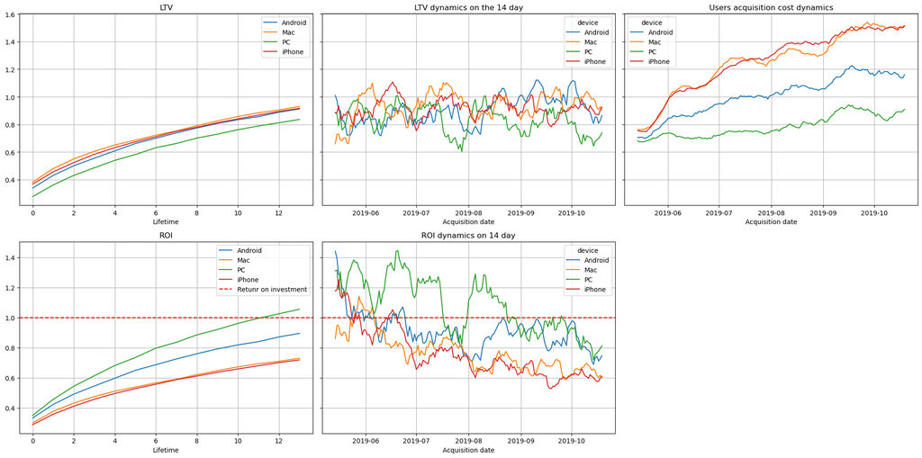

```python
ltv_raw, ltv_grouped, ltv_history, roi_grouped, roi_history = get_ltv(
    profiles, orders, observation_date, horizon_days, dimensions=['device']
)

plot_ltv_roi(
    ltv_grouped, ltv_history, roi_grouped, roi_history, horizon_days, window=14
)
```

LTV curves grow smoothly. LTV is the same for Android, Mac, iPhone users - the lines practically merge into one. LTV is the lowest for PC users.

The cost of attraction grows month on month for all devices. It must be down to ineffective ad channels across all devices. MAC and iPhone are the most impacted - the cost of engagement is highest here.

This dynamic affects ROI: by the end of the period, advertising pays off only on PCs. On Andriod the ROI reaches 90%, but never goes into profit. Ads on MAC and iPhone devices are the worst: here ROI stops at 75%

ROI dynamics: all devices are characterised by a downward trend. Profits are falling because the cost of admission is rising. PC advertising was profitable until mid-August, and then it goes into loss, as well as advertising on other devices.

### ROI by country

Let's analyse ROI by country. For this purpose, we will plot LTV and ROI, as well as graphs of LTV, CAC and ROI dynamics.

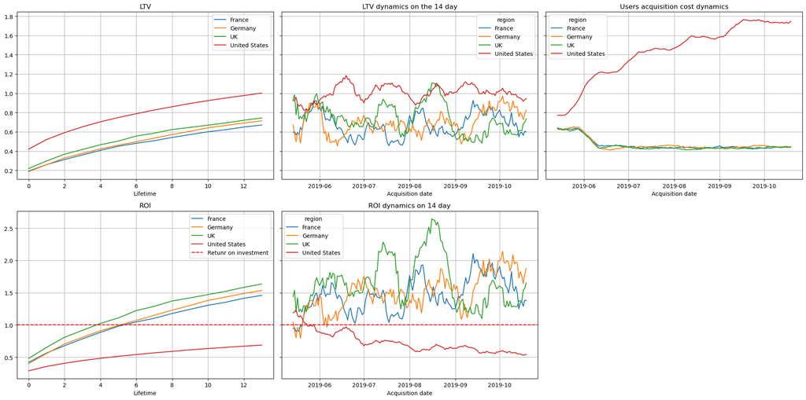

```python
ltv_raw, ltv_grouped, ltv_history, roi_grouped, roi_history = get_ltv(
    profiles, orders, observation_date, horizon_days, dimensions=['region']
)

plot_ltv_roi(
    ltv_grouped, ltv_history, roi_grouped, roi_history, horizon_days, window=14
)
```

The US has the best **LTV**, while the LTV curves for the other countries are at about the same level.

This is also where the most expensive users are located in the USA. **CAC** jumps here at the end of May and continues to grow. CAC for the rest of the countries (France, Germany, UK) is stable: the cost of engagement decreases during May and then stays at the same level throughout the period.

**ROI** - in France, Germany and the UK, advertising works very well: it pays off in the first half of the period. But in the US, the ROI curve grows very reluctantly and stops at 75%. The advertising campaign in the US does not pay off.

It seems that the point is that some advertising channels operating mainly in the US, mainly on MAC and iPhone, are inefficient and too expensive and are pulling the whole advertising campaign at a loss.

### ROI by advertising channel

Since advertising doesn't pay off only in the US, let's plot the graphs by advertising channel for this country only.

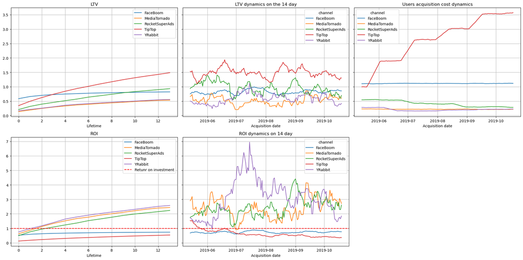

```python
profiles_us = profiles.query('region == "United States"')

ltv_raw, ltv_grouped, ltv_history, roi_grouped, roi_history = get_ltv(
    profiles_us, orders, observation_date, horizon_days, dimensions=['channel']
)

plot_ltv_roi(
    ltv_grouped, ltv_history, roi_grouped, roi_history, horizon_days, window=14
)
```

The graph of user acquisition cost dynamics shows that the two most expensive channels in the US are TipTop and FaceBoom. And on TipTop, the cost of engagement is growing every month. This is also the reason why advertising on these two channels does not pay off.

We remember that most of the total budget - 83% - was invested in these two channels. Spending on inefficient channels is so high that it leads to the whole advertising campaign not paying off.

TipTop is a very expensive channel that can't pay off, despite the fact that it is the 2nd largest channel in terms of the number of users attracted (19561) and the 4th largest in terms of the percentage of paying users (9.6%). Our recommendation is to stop working with this channel and redirect your money to cheaper and more effective channels.

The FaceBoom channel brings in the most paying users (12.2%) and it is twice as expensive as the other channels, but not as expensive as TipTop. It's not entirely clear why it's not paying off. Perhaps it's a matter of retention. Let's build conversion and retention graphs by channel.

### User conversion by channel

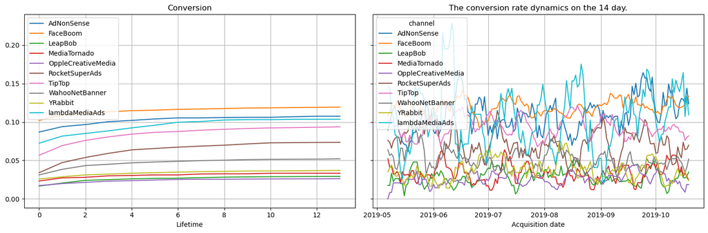

```python
dimensions = ['channel']

conversion_raw, conversion_grouped, conversion_history = get_conversion(
    profiles, orders, observation_date, horizon_days, dimensions=dimensions
)

plot_conversion(conversion_grouped, conversion_history, horizon_days)
```

The graphs confirm that the FaceBoom channel has the highest conversion rate. The graph of conversion dynamics shows that the channel is also quite stable: there are no strong jumps in the conversion percentage here, as, for example, on the lambdaMediaAds channel.

Let's check retention.

### User retention graphs by channel

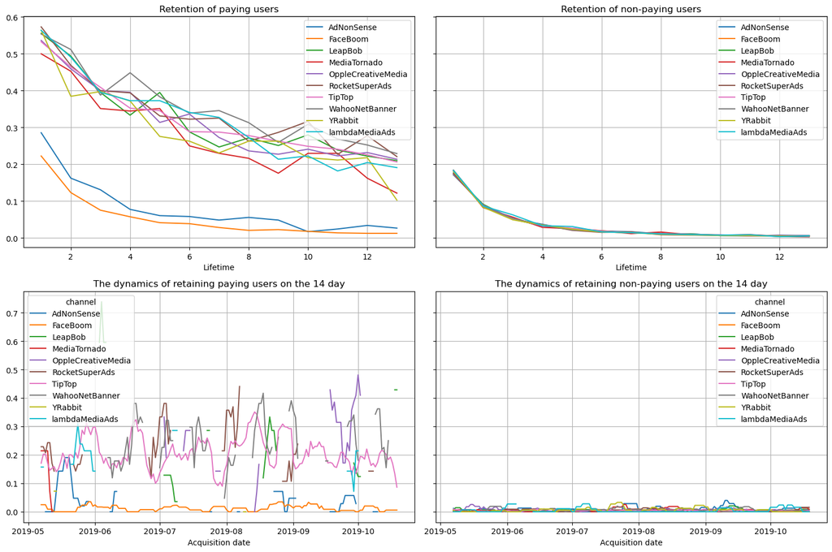

```python
retention_raw, retention_grouped, retention_history = get_retention(
    profiles, visits, observation_date, horizon_days, dimensions=dimensions
)

plot_retention(retention_grouped, retention_history, horizon_days)
```

The FaceBoom channel has the lowest user retention rate. Users coming from the AdNonSense channel also have a very poor retention rate.

The reason why the FaceBoom channel doesn't pay off is because it attracts a lot of users, but they are low quality users - they leave very quickly. And this is true for all countries, not just US users.

## Overall conclusion

We analysed the advertising campaign results for the Procrastinate Pro+ app.

We were provided with data from 1 May to 27 October 2019 - 6 months.

Ads were bought on 10 channels:

- TipTop,
- RocketSuperAds,
- YRabbit,
- FaceBoom,
- MediaTornado,
- AdNonSense,
- LeapBob,
- WahooNetBanner,
- OppleCreativeMedia,
- lambdaMediaAds

and was active in four countries:

- US,
- United Kingdom,
- France,
- Germany

We found out the percentage of paying users for each country:

- USA - 6.9%
- Germany - 4.11%
- Great Britain - 3.98%
- France - 3.8%

The most promising country for the app is the USA, as this country has the most users and simultaneously the highest percentage of paying users. Users attracted in this country are most likely to move to paying status.

The app is used on 4 types of devices:

- MS
- MAC
- Andriod
- iPhone

the most paying users on MAC and iPhone devices - 6.36% and 6.21 respectively. The least is on personal computers.

105'497 was spent on advertising during the period under review. Most of the total amount was invested in the channels

- TipTop - 51.90%
- FaceBoom - 30.75%

The other 8 channels accounted for only 17% of the total budget.

At the stage of analysing the dynamics of spending changes over time, we found out that spending on the TipTop channel was steadily growing. The same trend was reflected in the dynamics of the cost of attracting one client: CAC on this channel rose every month, while this indicator remained at the same level on the other channels.

FaceBoom channel is the second most expensive advertising channel. The cost here doesn't spike like the TipTop channel, but remains the most expensive when compared to the other 8 channels.

When we checked the ROI of the advertising campaign as a whole, we found out that it did not pay off.

The reason is the inefficiency of advertising in the US. The advertising campaigns in the rest of the countries paid off during the first half of the period under review, but the advertising campaign in the US was so ineffective that it dragged the overall result to a loss.

Next, we looked at the results of advertising in the US on different channels and found that there are 5 channels operating in the US:

- FaceBoom
- MediaTornado
- RocketSuperAds
- TipTop
- YRabbit

of which 3 paid off at the beginning of the period under review, and 2 never turned a profit: FaceBoom and TipTop

The reason for the unprofitable advertising campaign as a whole is that 83% of the total budget was allocated to unprofitable channels.

Advertising in other countries (except for the US) pays off very well, hence there is no need to adjust advertising campaigns in these countries.

There needs to be a change of strategy in the US.

This is the most promising country for the app. It is necessary to redirect advertising investments to more efficient channels.

The TipTop channel is too expensive, the cost of attracting one user on it is constantly growing. It is necessary to stop working with this channel.

**FaceBoom** channel. The situation with this channel is ambiguous. On the one hand, there is a very good percentage of attracting users and converting them into paying users; on the other hand, this channel does not pay off for two reasons: too expensive advertising, very poor retention rate. We recommend to check:

- Is there a possibility to reduce the cost of advertising on this channel? Perhaps choose another plan.
- Check what is the reason for the low retention rate of users coming from this channel. There might be some technical problem.

If it is possible to fix these two problems, you can continue working with this channel. If there is no such possibility, it is better to stop working with this channel.

We recommend switching to the following channels, prioritising them in this order:

1. the most promising channel - RocketSuperAds. The percentage of users switching to paying status here is 7.91% and the user retention rate is quite high.
2. YRabbit. The percentage of paying users - 3.83%, good retention rate, low cost of user acquisition - 0.25, which leads to a very good ROI. This channel paid off better than all the others, by ~260%.
3. MediaTornado. This channel has the same low cost per user - 0.25, and it paid off almost as well as the YRabbit channel. But it has the smallest (of these 3 channels) percentage of paying users - 3.57%, and also user retention is worse here than on the other 2 channels. That's why we put it on the third place.

Very little money was invested in these channels:

- 1,74%
- 0,9%
- 0,9% of the total budget, respectively.

Advertising on each of these three channels paid off by more than 200%.